# TweetsReport

### Numero medio de retuits recibidos

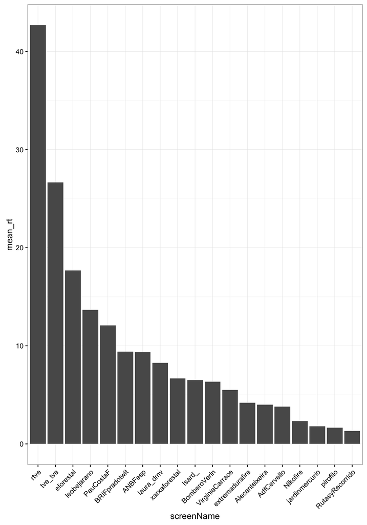

## Word cloud

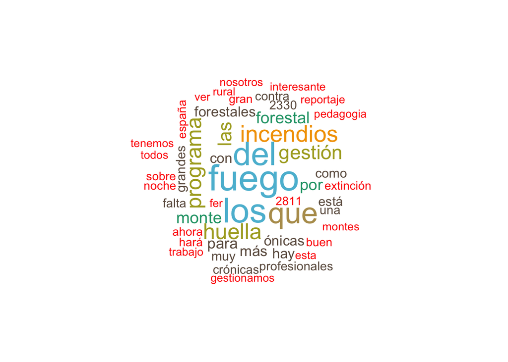

### Mentions: Twitter as a conversation platform

One of my favorite things about using Twitter at conferences though is its use as a forum for real-time conversation between participants. It has great potential to span different sessions, times, and physical boundaries. With ~2,000 attendees, you can’t possibly always meet up with the right group to discuss something you’re interested in. Who were some of the most active tweeters in conversations? We’ll begin looking into this by compiling a record of mentions by parsing the `text` field.

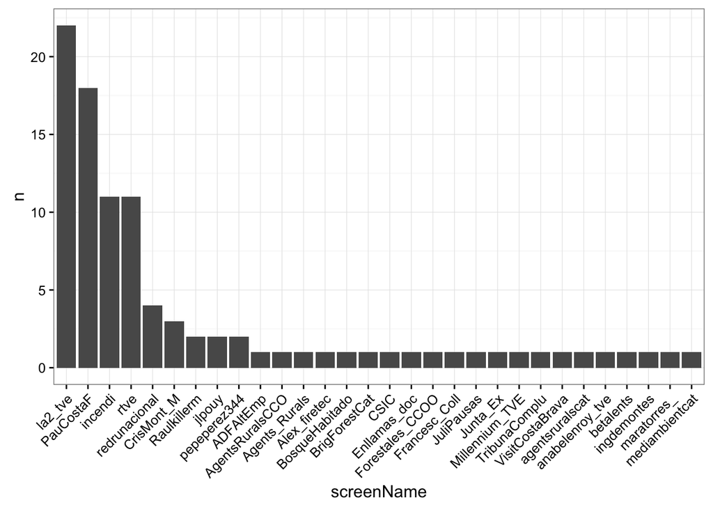

```r
# Note: this approach does not capture conversations in the form of "quoted" retweets, as they appear as hyperlinks in the text field. This also does not count retweets as mentions.

# Make a list of mentionees, index by mentioner
mentions <- regmatches(original_tweets_week$text,
                       gregexpr("@[-_A-Za-z0-9]+",
                                original_tweets_week$text))
mentions <- lapply(mentions, function(x) gsub("@", "", x)) # Strip off @
names(mentions) <- original_tweets_week$screenName
# Filter out non-mentioning tweets
mentions <- mentions[lapply(mentions, length) > 0]

# Who were the 30 most mentioned tweeters?
data.frame(screenName = unlist(mentions)) %>% tbl_df %>%
 group_by(screenName) %>%
 tally %>% arrange(-n) %>% slice(1:30) %>%
  transform(screenName = reorder(screenName, -n)) %>%
  ggplot(aes(screenName, n)) + geom_bar(stat = "identity") +
  theme_bw() + theme(axis.text.x = element_text(angle = 45, hjust = 1))
```